# 7강_퀴즈_koica

Author

최요한

Published

June 30, 2026

# 1 준비

## 1.1 사용할 패키지

```r
library(tidyverse)
library(readxl)     #xlsx 데이터 불러오기
library(writexl)    #xlsx 포맷으로 결과 출력하기
library(treemapify) #treemap
library(leaflet)    #지도 그기
library(showtext)   #한글 출력 패키지
showtext_auto()     #한글 출력하기
```

## 1.2 대륙별 담당

- 아시아: 김수진님, 박상애님, 박중열님, 방혜린님
- 아프리카: 신창민님, 오정민님, 정진실님, 박지원님
- 아메리카: 이정수님, 이하늬님, 이명희님, 이윤임님

KOICA 2024 OECD CRS

## 1.3 데이터 불러오기

> 불러온 koica 데이터를 “X2024_OECD_CRS” 변수명으로 저장합니다

> 아래 코드는 제 노트북의 경로입니다. 선생님들 노트북마다 경로가 다르므로 자신의 경로를 입력하세요.  
> 경로에 익숙하지 않으면 아래 펼쳐보기를 클릭해 Import Dataset을 사용해도 됩니다.

> Import Dataset은 변수명을 “X2024_OECD_CRS”으로 (동일하게) 저장할 것입니다

```r
read_xlsx("./2024+OECD+CRS.xlsx") -> X2024_OECD_CRS
```

**펼쳐보기**

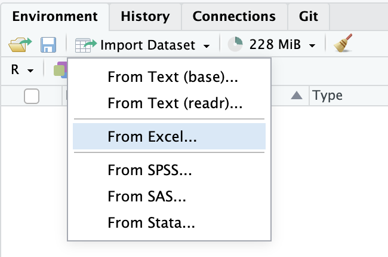

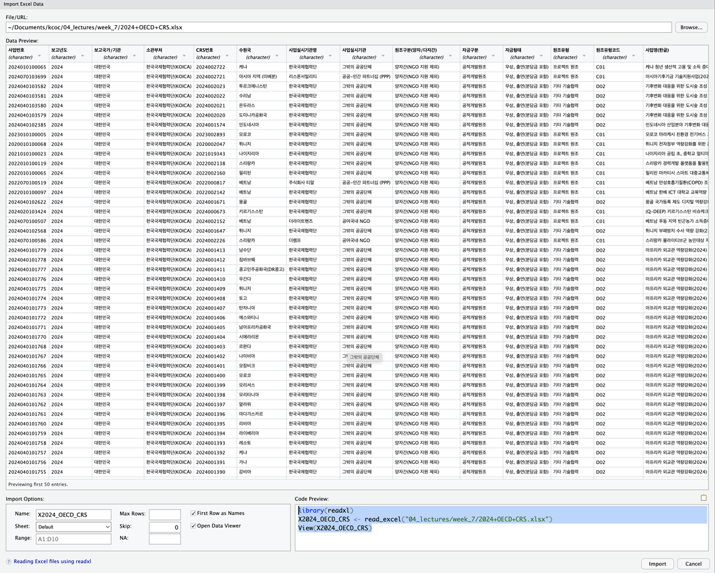

## 1.4 데이터셋을 복사(백업)합니다.

> X2024_OECD_CRS -> koica_1_2024xlsx

> 데이터를 분석하다보면 값이 엉키거나 몇 단계 전으로 되돌아가야할 경우가 있습니다

> 그 때를 대비해 불러온 데이터를 새로운 변수로 복사한 후 새로운 변수로 분석합니다(좋은 습관입니다)

```r
read_xlsx("./04_lectures/week_7/2024+OECD+CRS.xlsx")
```

X2024_OECD_CRS 불러온 데이터셋

koica_1_2024xlsx 복사해서 분석에 사용할 데이터셋

```r
X2024_OECD_CRS  -> koica_1_2024xlsx
```

## 1.5 데이터 살펴보기

> 전체 데이터를 훓어봅니다

# 2 퀴즈(기초)

## 2.1 변수 개수 확인

> 데이터는 몇 행, 몇 열입니까?

> glimpse

```
Rows: 3,004
Columns: 57
$ 사업번호                 <chr> "2024010100065", "2024070103699", "2024040103…
$ 보고년도                 <chr> "2024", "2024", "2024", "2024", "2024", "2024…
$ `보고국가/기관`          <chr> "대한민국", "대한민국", "대한민국", "대한민국", "대한민국", "대한민국…
$ 소관부처                 <chr> "한국국제협력단(KOICA)", "한국국제협력단(KOICA)", "한국국제협력단(…
$ CRS번호                  <chr> "2024002722", "2024002721", "2024002023", "20…
$ 수원국                   <chr> "케냐", "아시아 지역 (미배분)", "투르크메니스탄", "수리남", "온두라스…
$ 사업실시기관명           <chr> "한국국제협력단", "리스폰서빌리티", "한국국제협력단", "한국국제협력단", "…
$ 사업실시기관             <chr> "그밖의 공공단체", "공공-민간 파트너십 (PPP)", "그밖의 공공단체", "…
$ `원조구분(양자/다자간)`  <chr> "양자간(NGO 지원 제외)", "양자간(NGO 지원 제외)", "양자간(NGO …
$ 자금구분                 <chr> "공적개발원조", "공적개발원조", "공적개발원조", "공적개발원조", "공적개발…
$ 자금형태                 <chr> "무상, 출연(분담금 포함)", "무상, 출연(분담금 포함)", "무상, 출연(분…
$ 원조유형                 <chr> "프로젝트 원조", "프로젝트 원조", "기타 기술협력", "기타 기술협력", "…
$ 원조유형코드             <chr> "C01", "C01", "D02", "D02", "D02", "D02", "D0…
```

[output cut: 44 more lines]

## 2.2 변수명 확인

> 38번째 변수명은 무엇입니까?

> colnames()

```
 [1] "사업번호"               "보고년도"               "보고국가/기관"
 [4] "소관부처"               "CRS번호"                "수원국"
 [7] "사업실시기관명"         "사업실시기관"           "원조구분(양자/다자간)"
[10] "자금구분"               "자금형태"               "원조유형"
[13] "원조유형코드"           "사업명(한글)"           "사업분야"
[16] "사업분야코드"           "분야비율"               "SDGs"
[19] "지역"                   "사업개시(예정)일"       "사업완공(예정)일"
[22] "사업설명"               "성평등"                 "환경 지원"
[25] "민주적/포용적 거버넌스" "재난위험경감"           "장애인권리"
[28] "영양"                   "기술협력"               "기술협력 세부항목"
[31] "분야별 프로그램 원조"   "프로젝트 원조"          "혼합신용"
[34] "생물의 다양성"          "기후변화 완화"          "기후변화 적응"
[37] "사막화"                 "약정액"                 "지출액"
[40] "회수액"                 "비구속성 금액"          "부분 비구속성 금액"
[43] "구속성 금액"            "투자관련기술협력 금액"  "수출신용 금액"
[46] "약정일"                 "상환방식"               "연간상환횟수"
[49] "이자율"                 "최초상환일"             "최종상환일"
[52] "이자수취액"             "차관잔액"               "연체원금"
[55] "연체이자"               "차년도 상환원금"        "차년도 지불이자"
```

## 2.3 고유값 확인

> 변수의 고유값을 표형식으로 출력합니다

> sapply(), n_distnict, enframe(), print()

```
# A tibble: 57 × 2
   name                   value
   <chr>                  <int>
 1 사업번호                3004
 2 보고년도                   1
 3 보고국가/기관              1
 4 소관부처                   1
 5 CRS번호                 3004
 6 수원국                   132
 7 사업실시기관명           250
 8 사업실시기관              30
 9 원조구분(양자/다자간)      2
10 자금구분                   1
11 자금형태                   1
12 원조유형                   7
```

[output cut: 45 more lines]

## 2.4 결측값 확인

> 결측값의 분포를 대략 확인합니다.

> is.na(), colSums(), enframe(), print(n = Inf)

> 38번 항목 약정액에는 몇개의 결측값이 있나요?

```
# A tibble: 57 × 2
   name                  value
   <chr>                 <dbl>
 1 사업번호                  0
 2 보고년도                  0
 3 보고국가/기관             0
 4 소관부처                  0
 5 CRS번호                   0
 6 수원국                    0
 7 사업실시기관명            0
 8 사업실시기관              0
 9 원조구분(양자/다자간)     0
10 자금구분                  0
# ℹ 47 more rows
```

## 2.5 결측값 제로 변수

> 결측값이 없는 (모든 값이 다 들어있는) 변수는 몇개인가요?

> filter(value == 0)

```
# A tibble: 36 × 2
   name                  value
   <chr>                 <dbl>
 1 사업번호                  0
 2 보고년도                  0
 3 보고국가/기관             0
 4 소관부처                  0
 5 CRS번호                   0
 6 수원국                    0
 7 사업실시기관명            0
 8 사업실시기관              0
 9 원조구분(양자/다자간)     0
10 자금구분                  0
# ℹ 26 more rows
```

## 2.6 특정 조건 정렬

> 지출액이 가장 큰 사업 10개의 사업번호, 사업실시기관명, 지출액, 수원국, 사업명(한글)을 출력하시오

> arrange(), desc(), select()

```
# A tibble: 3,004 × 5
   사업번호      사업실시기관명   지출액 수원국                   `사업명(한글)`
   <chr>         <chr>             <dbl> <chr>                    <chr>
 1 2024110103826 한국국제협력단 83983816 그외 지역 또는 다수국가 (미배분)…… 행정성경비
 2 2024010103719 한국국제협력단  9585881 아시아 지역 (미배분)     아시아태평양지역 예비조사…
 3 2024030701566 한국국제협력단  8392833 그외 지역 또는 다수국가 (미배분)…… KOICA 개발협력 사업…
 4 2024100103825 한국국제협력단  7993611 그외 지역 또는 다수국가 (미배분)…… 개발인식증진
 5 2024019903721 한국국제협력단  5757822 아프리카 지역 (미배분)   아프리카지역 예비조사, …
 6 2016010360809 한국국제협력단  5704321 이라크                   이라크 중환자 전문의료 …
 7 2023010100107 한국국제협력단  5696658 키르기스스탄             키르기스스탄 국가 에너지…
 8 2024010103865 유엔아동기금    5075021 짐바브웨                 (분쟁취약) (짐바브웨)…
 9 2015010319841 한국국제협력단  4899057 스리랑카                 스리랑카 기술계 교사 양…
10 2022010100094 유엔개발계획    4667516 베트남                   베트남 지뢰/불발탄 제거…
# ℹ 2,994 more rows
```

# 3 퀴즈(기본)

## 3.1 기술 통계 및 요약

> `사업실시기관명`별로 총 지출액의 합계, 평균, 총 사업 수 요약하세요

> group_by(), reframe(), mean(), sum(), n(), arrange(), desc()

```
# A tibble: 250 × 4
   사업실시기관명     지출액합계 지출액평균 총사업수
   <chr>                   <dbl>      <dbl>    <int>
 1 한국국제협력단      563083187    236094.     2385
 2 공여국내 NGO          6163346     55030.      112
 3 유엔개발계획         32174498    766059.       42
 4 유엔아동기금         37840058   1455387.       26
 5 세계식량계획         34945413   1456059.       24
 6 국제이주기구         28583151   1361102.       21
 7 유엔인구기금         26160643   1308032.       20
 8 글로벌녹색성장기구   13659537    853721.       16
 9 유엔난민기구         16391613   1490147.       11
10 세계보건기구          7488934    936117.        8
# ℹ 240 more rows
```

## 3.2 지출액 규모

> 지출액의 분포를 파악하고자 합니다.

> x축 = 지출액 히스토그램을 그리세요

> geom_histogram()

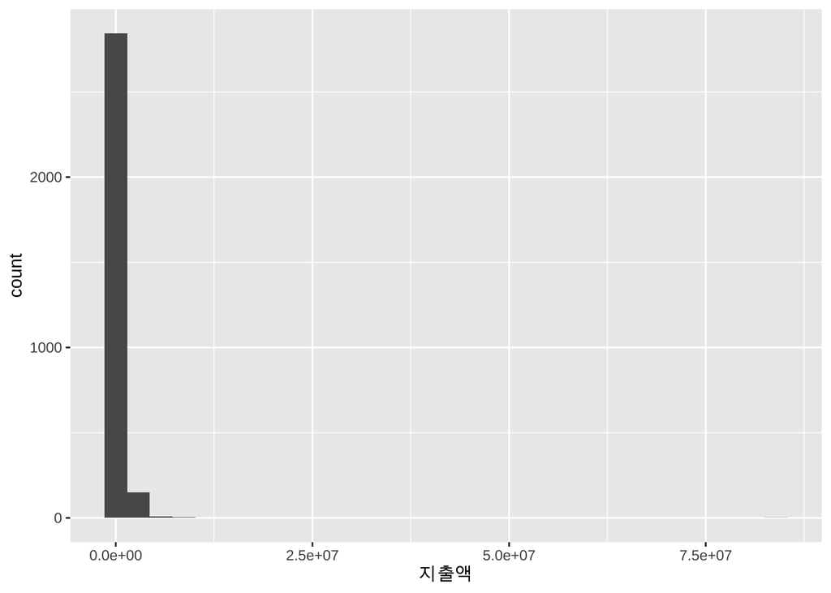

## 3.3 지출액 크기

> 지출액과 약정액의 분포를 파악하고자 합니다.

> x축 = 약정액, y축 = 지출액 산점도를 그리세요

> geom_point()

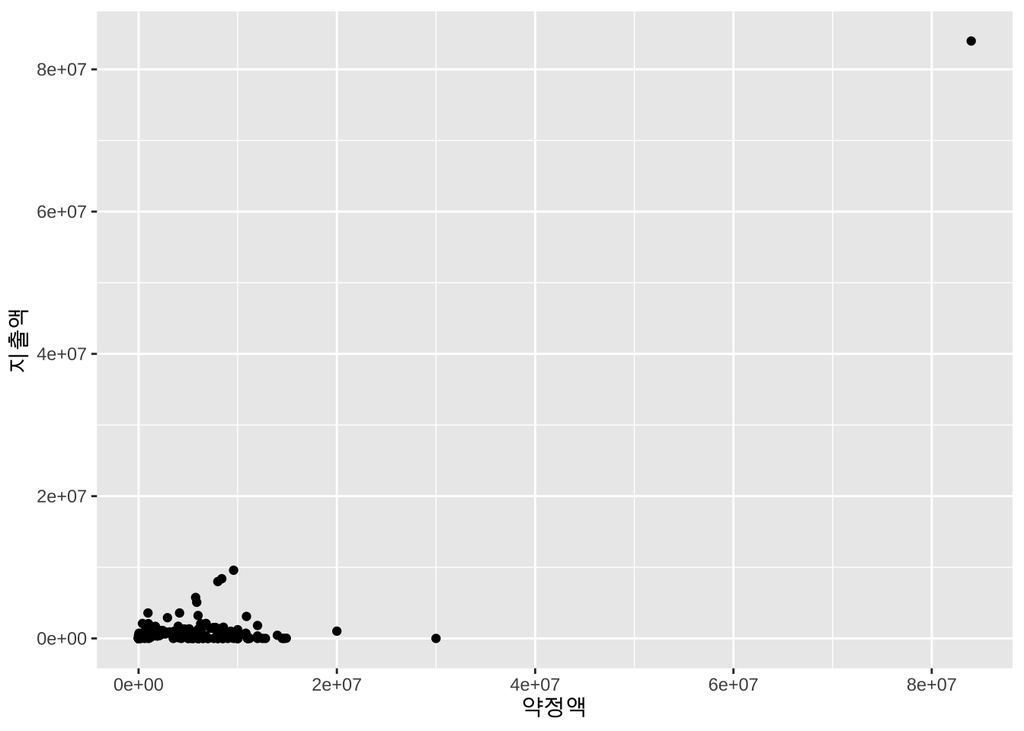

## 3.4 아웃라이어 제거

> 지출액과 약정액이 80,000,000 을 초과하는 사업이 1건 있습니다.

> 지출액이 80,000,000을 초과하는 사업의 원조유형은 무엇인가요?

> 80,000,000이라는 큰 숫자가 시각화 분석을 방해하므로 제외한 후 히스토그램을 그리세요

> geom_point(), geom_histogram()

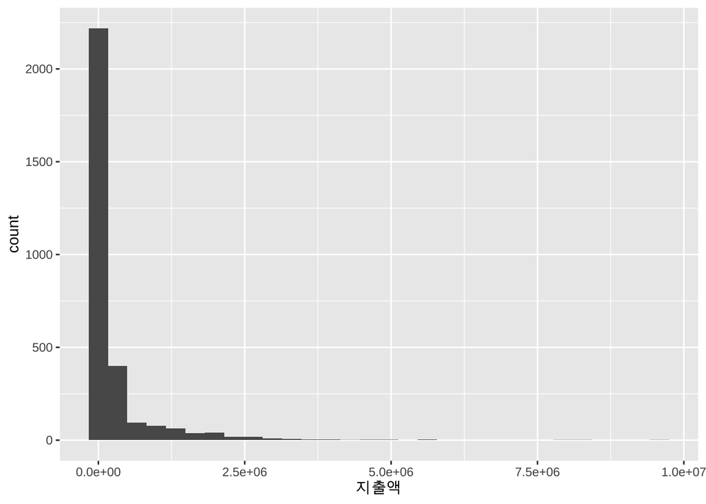

# 4 퀴즈(어려움)

## 4.1 원조유형별 사업건당 평균 지출액

> 원조유형별 사업건수와 전체 지출액, 사업건당 평균 지출액을 표로 출력하세요

> group_by(원조유형)

> reframe(), n(), sum()

```
# A tibble: 7 × 4
  원조유형                               사업건수 지출액합계 사업건당_지출액평균
  <chr>                                     <int>      <dbl>               <dbl>
1 개도국 유학생 및 연수생 지원                916   13595971              14843.
2 개발에 대한 인식 확산                         1    7993611            7993611
3 개발협력 수행과 관련된 행정비용               2   84388028           42194014
4 기타 기술협력                               460   28326998              61580.
5 전문가 및 봉사단 파견                       673   86862793             129068.
6 프로젝트 원조                               951  656896954             690743.
7 합동기금(Basket funds/Pooled funding) 지원……        1    3536628            3536628
```

## 4.2 원조유형별 사업건당 평균 지출액 시각화

> 위에서 그린 표를 트리맵으로 시각화 하세요

> geom_treemap(), geom_treemap_text()

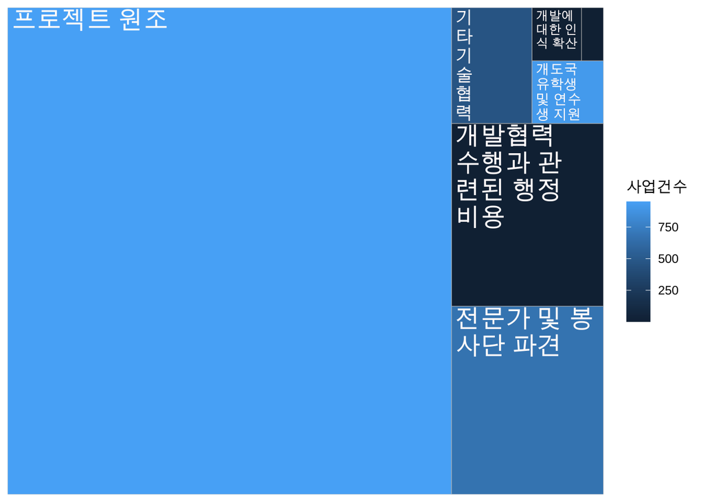

**막대그래프 참고**

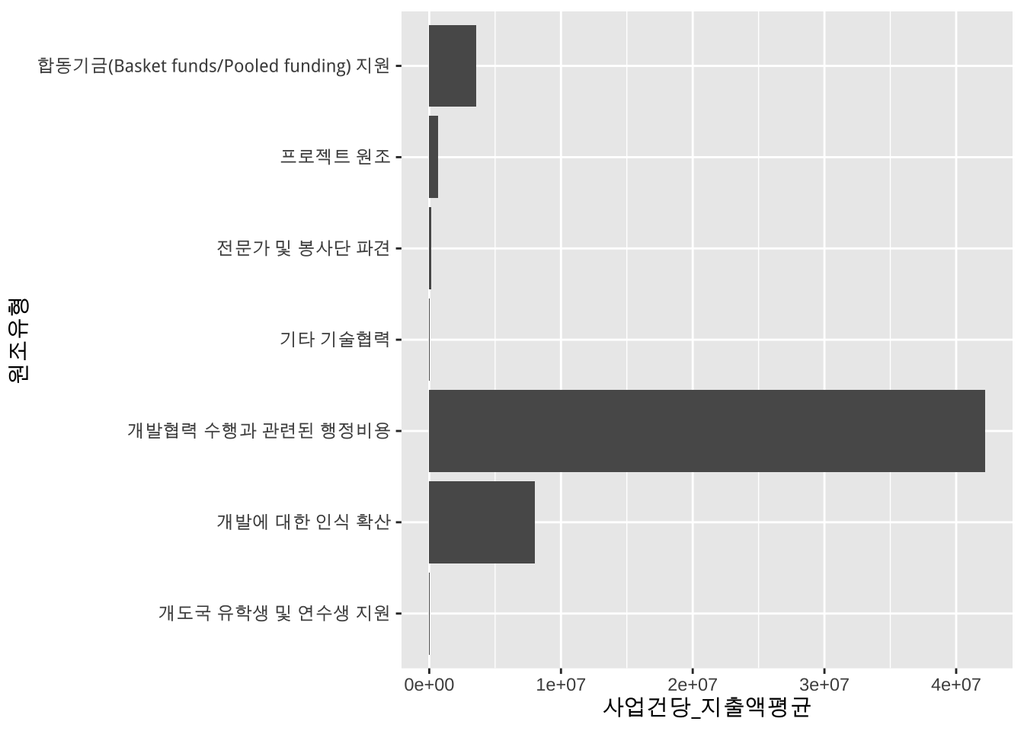

```r
koica_1_2024xlsx |>
  group_by(원조유형) |>
  reframe(사업건수 = n(),
          지출액합계 = sum(지출액),
          사업건당_지출액평균 = 지출액합계 / 사업건수) |>
  ggplot(aes(x = 원조유형, y = 사업건당_지출액평균)) +
  geom_bar(stat = 'identity') +
  coord_flip()
```

## 4.3 약정액 대비 지출액 비율

> 지출액을 약정액으로 나누어 지출액비율을 만들고

> 약정액보다 지출액이 많은 사업을 모두 출력하세요

> drop_na(), mutate(), select(), filter()

```
# A tibble: 31 × 5
   사업번호      사업실시기관명                         지출액비율 지출액 약정액
   <chr>         <chr>                                       <dbl>  <dbl>  <dbl>
 1 2023070100417 사단법인 메디피스                           127.  375987   2956
 2 2023070100509 어린이재단                                   78.1 286023   3664
 3 2023070100403 사회복지법인 월드비전                        51.8 366696   7078
 4 2022070100399 초록우산 어린이재단                          37.9 256687   6767
 5 2023070100438 한국해비타트                                 24.2 366696  15154
 6 2019010100062 한국국제협력단                               16.9 337802  20000
 7 2021070101657 지구촌나눔운동                               16.9 733392  43452
 8 2023070100521 사회복지법인 밀알복지재단, 향기내는사람들……       15.4 461114  30031
 9 2023070100550 사단법인 비전케어                            10.5 256274  24378
10 2023070100534 (사)한국국제기아대책기구                     10.0 301930  30045
# ℹ 21 more rows
```

## 4.4 엑셀파일 저장

> 약정액 대비 지출액 비율이 높은 순서대로 내림차순한 후 엑셀파일로 출력하세요.

> > 엑셀파일명: 초과지출사업.xlsx

> > writexl 패키지

> > write_xlsx()

## 4.5 사업실시기관명 평균 지출액 차이

> ‘국제이주기구’, ‘유엔아동기금’ 간의 평균 지출액 차이를 t-검정하세요
> - 국제이주기구: 1,361,102
> - 유엔아동기금: 1,455,387

> > 단일표본, 독립표본, 대응표본 t-검정 중 어떤 검정을 해야 하나요?

> > 두 단체의 평균 지출액 t-검정 결과는 어떠한가요?

```r
koica_1_2024xlsx |>
  filter(사업실시기관명 %in% c("국제이주기구", "유엔아동기금")
         ) -> koica_5_2024ttest

koica_5_2024ttest |>
  group_by(사업실시기관명) |>
  reframe(평균지출액 = mean(지출액),
          n = n())
```

```
# A tibble: 2 × 3
  사업실시기관명 평균지출액     n
  <chr>               <dbl> <int>
1 국제이주기구     1361102.    21
2 유엔아동기금     1455387.    26
```

```
    Welch Two Sample t-test

data:  지출액 by 사업실시기관명
t = -0.25574, df = 43.983, p-value = 0.7993
alternative hypothesis: true difference in means between group 국제이주기구 and group 유엔아동기금 is not equal to 0
95 percent confidence interval:
 -837309.0  648740.1
sample estimates:
mean in group 국제이주기구 mean in group 유엔아동기금
                   1361102                    1455387
```

> 표준편차를 구해 두 단체의 평균지출액을 확인하세요

**표준편차 확인하기**

```r
koica_5_2024ttest |>
  group_by(사업실시기관명) |>
  summarise(
    데이터개수 = n(),
    최솟값 = min(지출액),
    중앙값 = median(지출액),
    최대값 = max(지출액),
    표준편차 = sd(지출액)
  )
```

```
# A tibble: 2 × 6
  사업실시기관명 데이터개수 최솟값  중앙값  최대값 표준편차
  <chr>               <int>  <dbl>   <dbl>   <dbl>    <dbl>
1 국제이주기구           21      0 1158659 3896887 1026120.
2 유엔아동기금           26      0 1204246 5075021 1493433.
```

> 박스플롯을 시각화해 데이터의 퍼짐 정도를 확인하세요

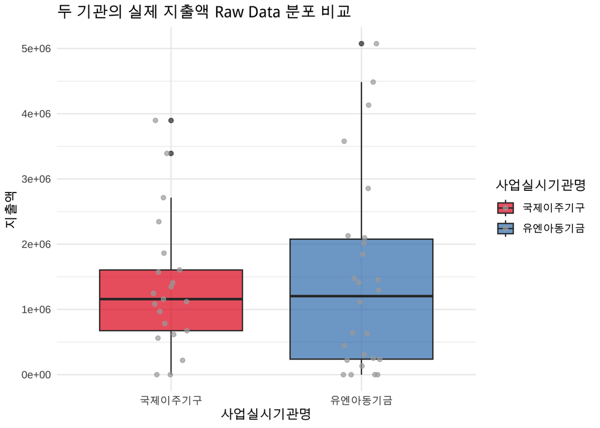

```r
koica_5_2024ttest |>
  ggplot(aes(x = 사업실시기관명, y = 지출액, fill = 사업실시기관명)) +
  geom_boxplot(alpha = 0.7) +
  geom_jitter(width = 0.1, alpha = 0.7, color = "darkgrey") +
  theme_minimal() +
  labs(title = "두 기관의 실제 지출액 Raw Data 분포 비교") +
  scale_fill_brewer(palette = 'Set1')
```

퀴즈 끝.

## 4.6 지도 그리기 (AI)

> AI를 활용해 지역별로 풀어보세요
> - 아시아: 김수진님, 박상애님, 박중열님, 방혜린님
> - 아프리카: 신창민님, 오정민님, 정진실님, 박지원님
> - 아메리카: 이정수님, 이하늬님, 이명희님, 이윤임님

### 4.6.1 지역 분리하기

> 아메리카 > 남아메리카 처럼 지역이 2~3개로 묶여 있습니다.

> 지역을 대륙, 지역1, 지역2처럼 3개의 변수로 분리해 “koica_4_2024separate’변수에 저장하세요

> “koica_4_2024separate” 변수에서 사업번호, 대륙, 지역1, 지역2만 출력하세요

> separate_wider_delim()

```r
koica_1_2024xlsx |>
  separate_wider_delim(
    지역,
    delim = " > ",
    names = c("대륙", "지역1", "지역2"),
    too_few = "align_start"
    #too_many = "merge"
  ) -> koica_4_2024separate

koica_4_2024separate |>
  select(사업번호, 수원국, 대륙, 지역1, 지역2)
```

```
# A tibble: 3,004 × 5
   사업번호      수원국               대륙     지역1              지역2
   <chr>         <chr>                <chr>    <chr>              <chr>
 1 2024010100065 케냐                 아프리카 사하라 이남        동부아프리카
 2 2024070103699 아시아 지역 (미배분) 아시아   아시아 미배분      <NA>
 3 2024040103582 투르크메니스탄       아시아   서남 및 중앙아시아 <NA>
 4 2024040103581 수리남               아메리카 남아메리카         <NA>
 5 2024040103580 온두라스             아메리카 중앙 아메리카      <NA>
 6 2024040103579 도미니카공화국       아메리카 카리브해           <NA>
 7 2024040102385 인도네시아           아시아   극동 아시아        <NA>
 8 2023010100005 모로코               아프리카 사하라 이북        <NA>
 9 2020010100068 튀니지               아프리카 사하라 이북        <NA>
10 2021010100023 나이지리아           아프리카 사하라 이남        서부아프리카
# ℹ 2,994 more rows
```

### 4.6.2 아래 3개 도시의 지도를 출력하세요

> koica_4_2024separate

> 아시아: 투르크메니스탄 (수도: 아쉬하바드)

[interactive chart not shown]

> koica_4_2024separate

> 튀니지 (수도: 튀니스)

[interactive chart not shown]

> koica_4_2024separate

> 수리남 (수도: 파라마리보)

[interactive chart not shown]

# 5 보너스 퀴즈 (심화)

## 5.1 성평등 관련 지출액 비중

> 성평등 항목 중 “관련내용이 주요(1차적) 목적인 경우”의 총지출액을 (선생님이 담당하는) 대륙에서 지역1, 지역2로 출력하세요

> koica_4_2024separate, filter(), group_by(), reframe(), sum(), n()

```
# A tibble: 13 × 5
   대륙       지역1              지역2        총지출액 사업건수
   <chr>      <chr>              <chr>           <dbl>    <int>
 1 아메리카   남아메리카         <NA>          6023801       12
 2 아메리카   중앙 아메리카      <NA>           382834        3
 3 아메리카   카리브해           <NA>          3400145        6
 4 아시아     극동 아시아        <NA>          7745287       52
 5 아시아     서남 및 중앙아시아 <NA>          9390106       28
 6 아시아     중동               <NA>          7985731        6
 7 아프리카   사하라 이남        동부아프리카 20215968       43
 8 아프리카   사하라 이남        서부아프리카  5544942       16
 9 아프리카   사하라 이남        중부아프리카  8000990        9
10 아프리카   사하라 이북        <NA>          2125036        6
11 오세아니아 멜라네시아         <NA>          2864420        4
12 오세아니아 미크로네시아       <NA>            58978        2
13 오세아니아 폴리네시아         <NA>            29489        1
```

## 5.2 히트맵 시각화

> 위 내용을 자신이 담당하는 지역의 히트맵으로 시각화하세요 (오세아니아 예시)

> geom_tile(), geom_text(), theme_minimal(), theme()

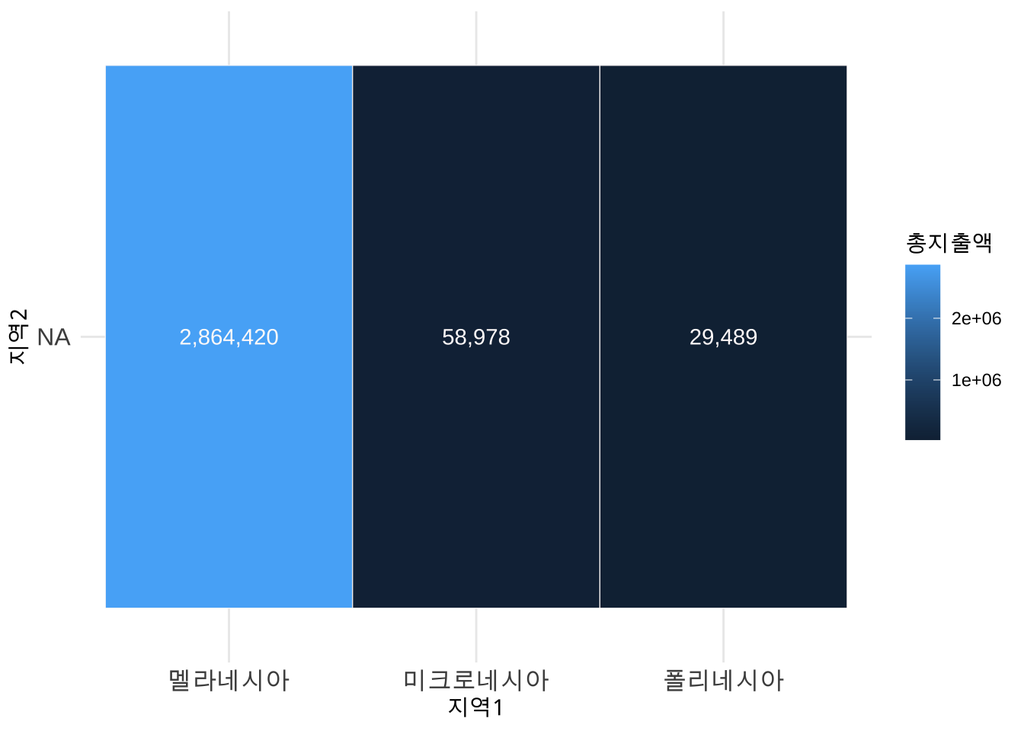

```r
koica_4_2024separate |>
  filter(성평등 == '관련내용이 주요(1차적) 목적인 경우') |>
  filter(대륙 == '오세아니아') |>
  group_by(대륙, 지역1, 지역2) |>
  reframe(총지출액 = sum(지출액),
          사업건수 = n()) |>
  ggplot(aes(x = 지역1, y = 지역2, fill = 총지출액)) +
  geom_tile(color = 'snow') +
  geom_text(aes(label = scales::comma(총지출액)), color = 'snow') +
  theme_minimal() +
  theme(
    axis.text = element_text(size = 12)
  )
```

## 5.3 대륙, 지역1별 지출액 분포

> 지출액의 비중을 x축 = 지역1, y축 = 지역2로 히트맵으로 보기

> 위의 코드를 활용합니다.

**오세아니아 예시**

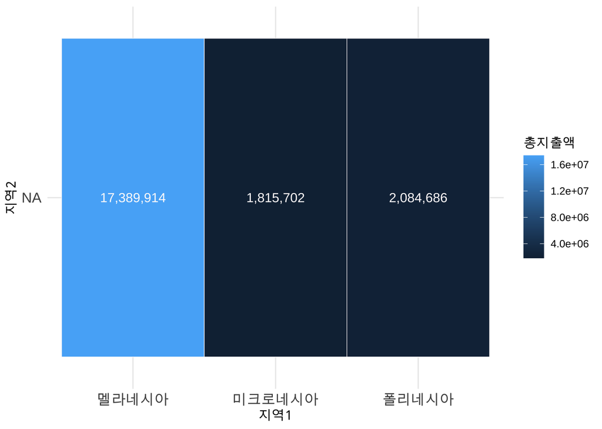

```r
koica_4_2024separate |>
  #filter(성평등 == '관련내용이 주요(1차적) 목적인 경우') |>
  filter(대륙 == '오세아니아') |>
  group_by(대륙, 지역1, 지역2) |>
  reframe(총지출액 = sum(지출액),
          사업건수 = n()) |>
  ggplot(aes(x = 지역1, y = 지역2, fill = 총지출액)) +
  geom_tile(color = 'snow') +
  geom_text(aes(label = scales::comma(총지출액)), color = 'snow') +
  theme_minimal() +
  theme(
    axis.text = element_text(size = 12)
  )
```

## 5.4 면분할

> 위 그래프에서 자신의 대륙만 선택해 시각화하세요

> x축 = 지역1, y 축= 지역2로 설정하세요

**아프리카 예시**

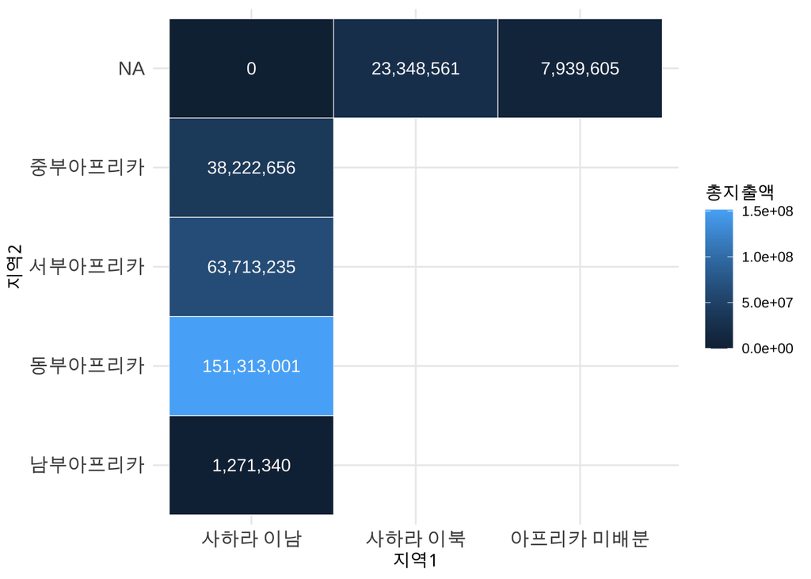

```r
koica_4_2024separate |>
  filter(대륙 %in% c('아프리카'))|>
  group_by(지역1, 지역2) |>
  reframe(총지출액 = sum(지출액),
          사업건수 = n()) |>
  ggplot(aes(x = 지역1, y = 지역2, fill = 총지출액)) +
  geom_tile(color = 'snow') +
  geom_text(aes(label = scales::comma(총지출액)), color = 'snow') +
  theme_minimal() +
  theme(
    axis.text = element_text(size = 12)
  )
```

## 5.5 주요 수원국 비교

> 수원국별로 사업건수를 조회하세요

> 사업건수가 많은 수원국 상위 10개를 막대그래프로 시각화하세요

> count(), slice(), geom_bar(), geom_label(), theme_minimal(), theme()

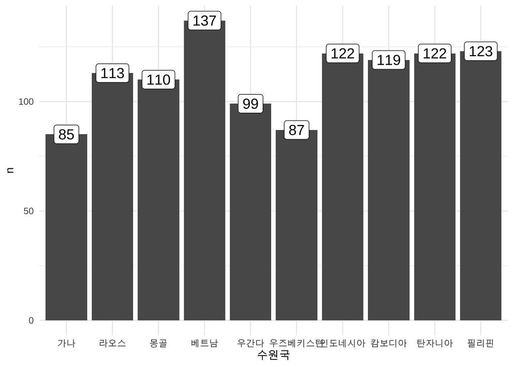

## 5.6 막대그래프 정렬

> 사업건수가 많은 순서대로 막대그래프로 정렬하세요

> ggplot(aes(x = 수원국 |> fct_reorder(desc(n)), y = n))

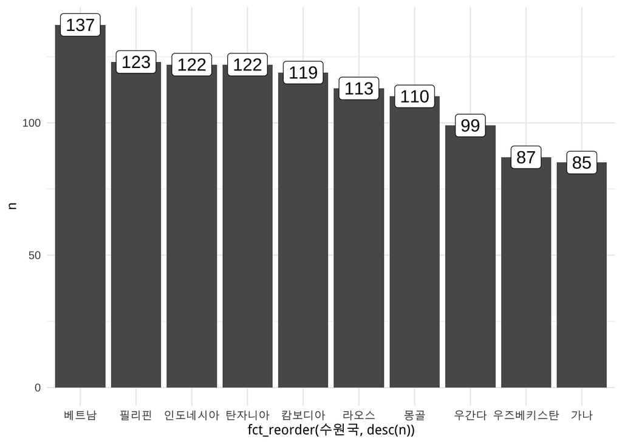

## 5.7 상관관계

> 약정액과 지출액의 상관관계를 구하세요.

> > 스피어만 vs 피어슨 상관계수

> > 아웃라이어 포함 vs 제외

```r
koica_1_2024xlsx |>
  drop_na(약정액, 지출액) -> koica_2_2024dropna

cor(koica_2_2024dropna$약정액,
    koica_2_2024dropna$지출액,
    method = "spearman")
```

```
[1] 0.8674711
```

```r
cor(koica_2_2024dropna$약정액,
    koica_2_2024dropna$지출액,
    method = "pearson")
```

```
[1] 0.7191364
```

```r
koica_2_2024dropna |>
  filter(약정액 < 80000000) -> koica_3_2024dropnafilter

cor(koica_3_2024dropnafilter$약정액,
    koica_3_2024dropnafilter$지출액,
    method = "spearman")
```

```
[1] 0.8673023
```

```r
cor(koica_3_2024dropnafilter$약정액,
    koica_3_2024dropnafilter$지출액,
    method = "pearson")
```

```
[1] 0.3589583
```

# 6 끝.

수고 많으셨습니다.